# Multivariate models for the BPA/BPS vs growth outcomes

SINCE LAST TIME:

- TCS models
- different presentation of sex interaction
- answer to a question raised last time: all birth outcomes measured once (and not 3 times) on the day of birth (info from carnet de santé)

TO DISCUSS:

- p-vals for male effect (for now betas and CIs are male effect but the p’s are interaction p’s)
- Latest results
- Final list of tables and figures for paper
- final expo coding (raw, ln, tertile, GM?)
- Abstract?

PENDING:

- Post nat data

TO DO:

- Get day 3 HC measure + check Ns and re-run analysis + copmpare birth day measure with D3 measure
- compare results to litterature
- check residuals outliers for T2 and T3 femur length models and head circumference
- Do analysis on raw BPA (not corrected for batch and protocol variables)

Note on head circumference: data currently presented is data from carnet de santé and is measured the day of the exam by the clinic doctors. Another measure is perfomed approx 3 days later for sepages. I don’t have this data yet and according to Sarah there might be up to 50% missing (19/11/19).

# 1 Intro

This document is a first draft to show the model outputs of the analysis “exposure to BPA/BPS during pregnancy vs growth outcomes”.

Included outcomes are:

```
##  [1] "femur_length_T2"            "femur_length_T3"
##  [3] "abdominal_circumference_T2" "abdominal_circumference_T3"
##  [5] "biparietal_diameter_T2"     "biparietal_diameter_T3"
##  [7] "head_circumference_T2"      "head_circumference_T3"
##  [9] "head_circ"                  "birth_length"
## [11] "birth_weight"
```

Measures for the outcome were standardised (division by SD) in order to make the betas comparable between outcomes.

BPA data are the standardised values ie corrected for batch and other protocol vars.

BPS data are presented as detected/undetected due to the relatively small number of samples between LOD and LOQ.

Models presented are

- Main models
  - outcomes ~ untransformed and standardized BPA & TCS at T2 and T3
  - outcomes ~ detected/undetected levels of BPS at T2 and T3
- Secondary models
  - outcomes ~ ln transform of standardised BPA & TCS at T2 and T3
  - outcomes ~ tertiles of standardised BPA & TCS at T2 and T3
  - outcomes ~ geometric mean of BPA
  - outcomes ~ cumulative BPS (detected never, at T2, at T3, at T2 and T3)

# 2 Visualisation

Here we observe for potential outliers.

## 2.1 Ultrasound data

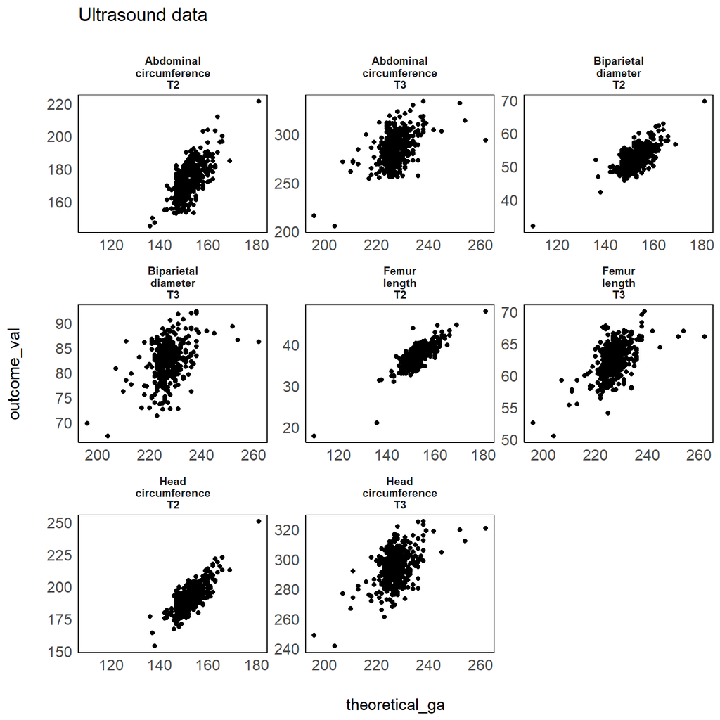

No outliers because ga modeled as 2nd order polynome: **GA + GA^2**.

## 2.2 Birth data

All birth outcomes are measured once on the day of birth.

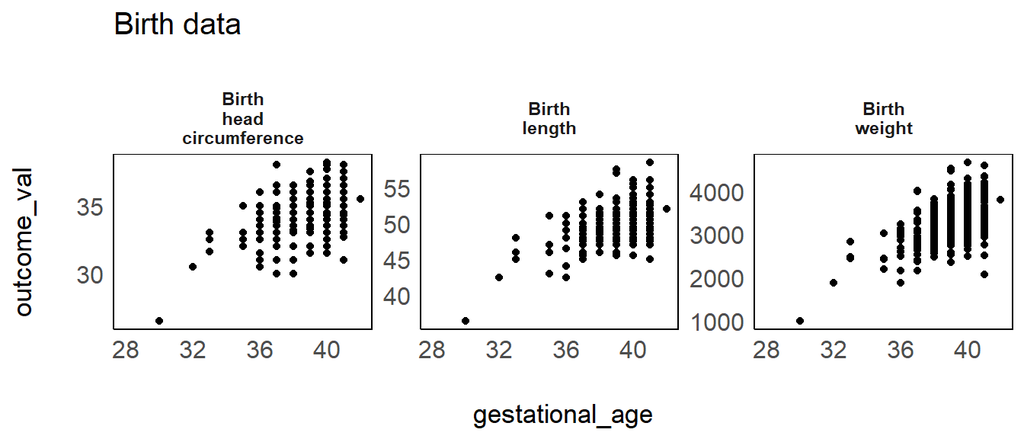

No outliers because ga modeled as 2nd order polynome: **GA + GA^2**.

# 3 Correlation between outcomes

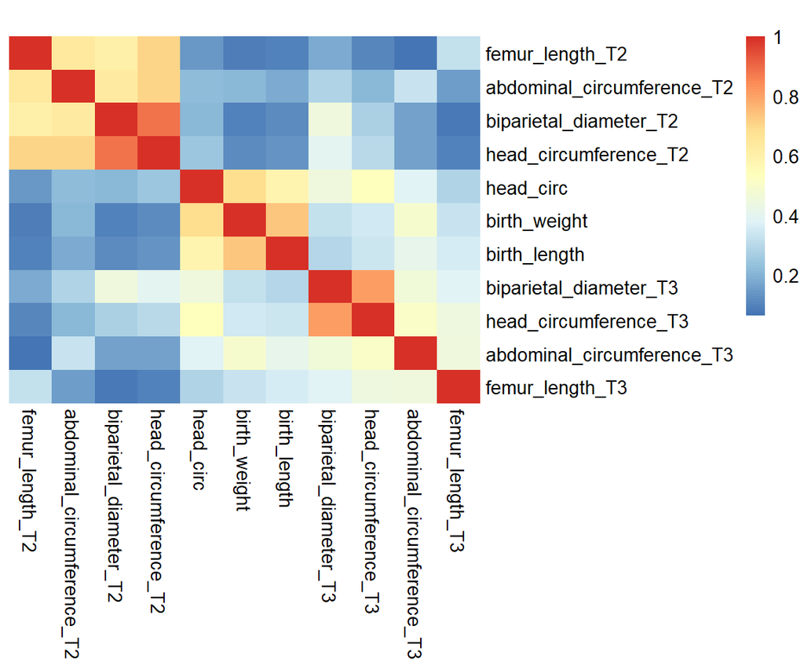

Correlation between biparietal diameter and head circumference

- 0.89 at T2
- 0.80 at T3

=> Select head circumference for pregnancy outcomes.

# 4 Main results

Here I show betas from the main models. **Outcome data are standardised by outcome_val/sd to make betas comparable**.

## 4.1 Summary of main results

Residuals OK (**a couple of outliers to check for T2 and T3 femur length models and head circumference at birth**)

## 4.2 BPA

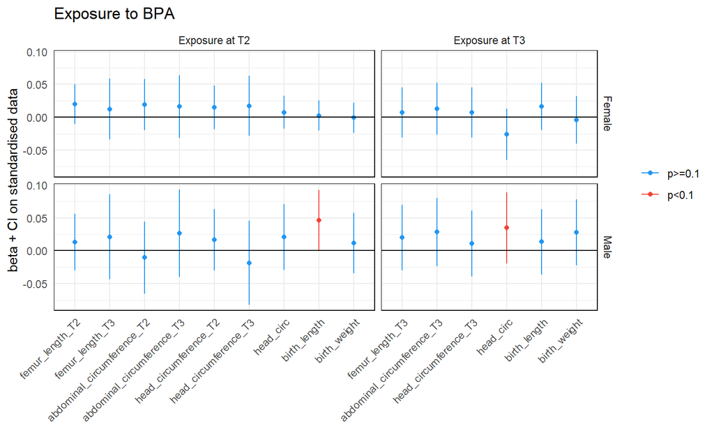

## 4.3 BPS

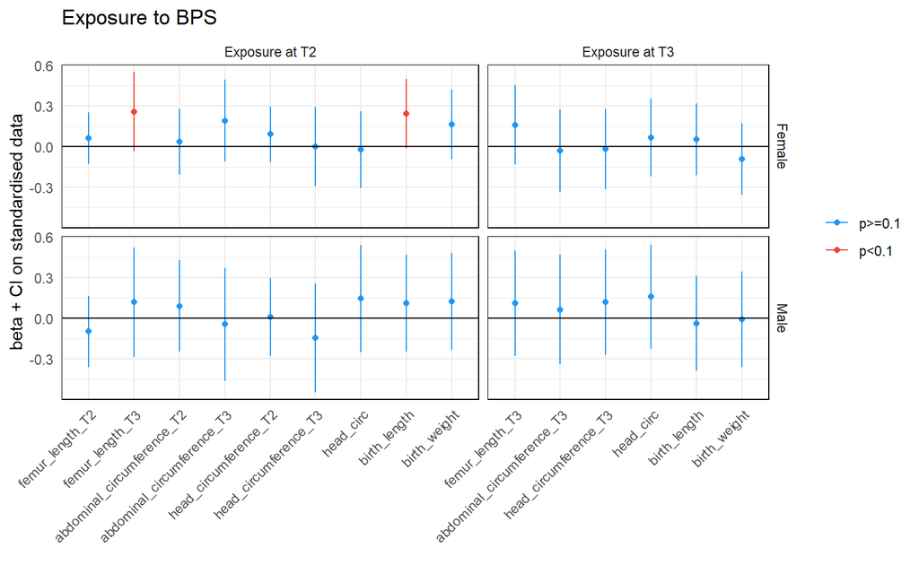

## 4.4 Triclosan

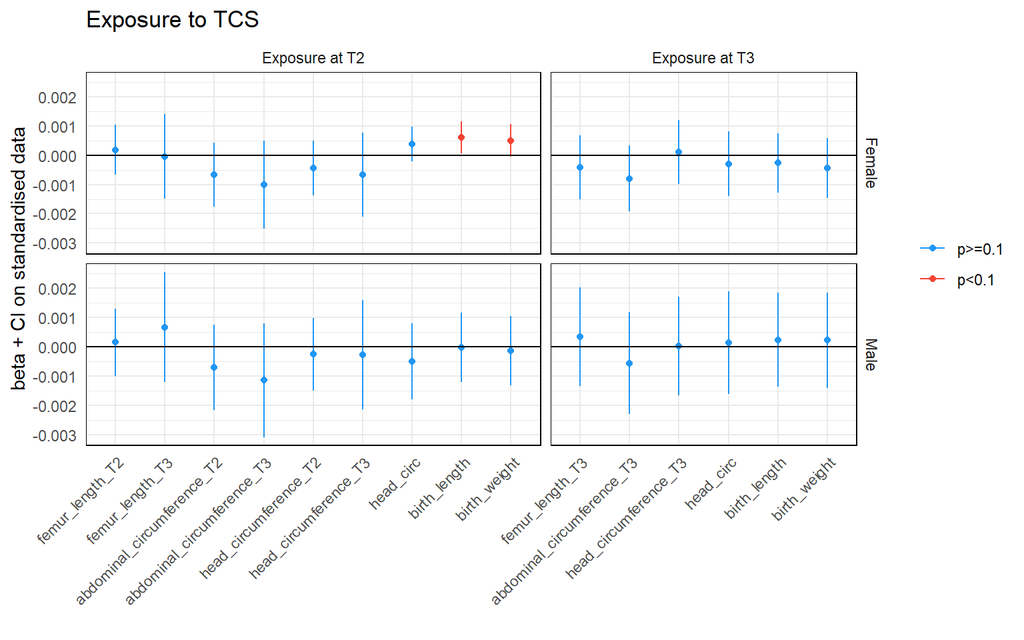

# 5 Secondary results

## 5.1 ln(BPA)

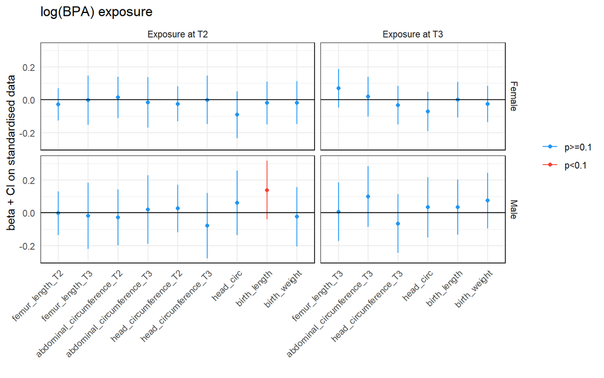

## 5.2 BPA tertiles

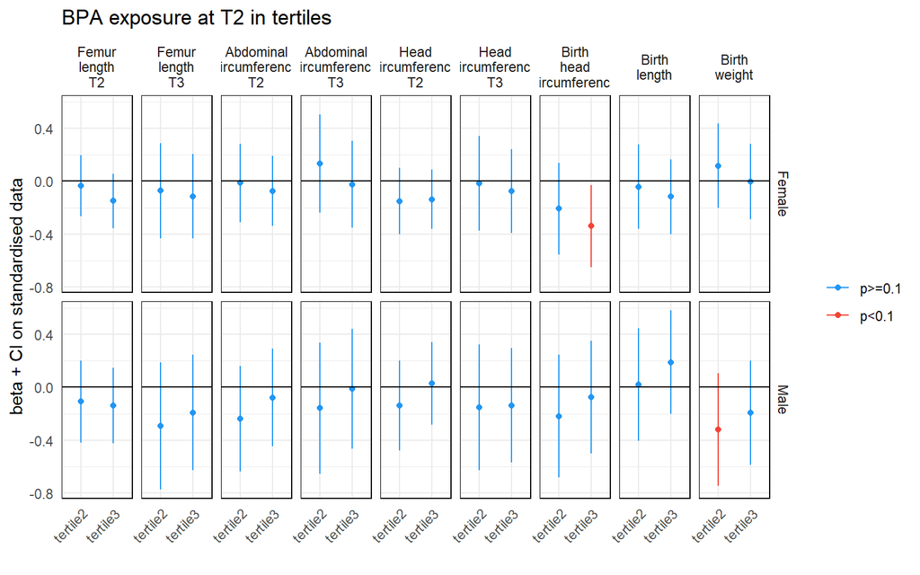

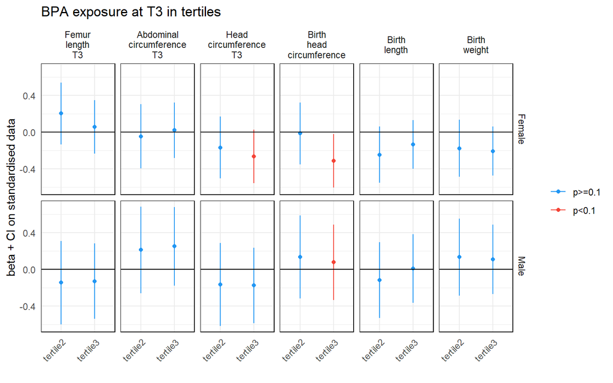

## 5.3 BPA geometric mean

Geometric mean of BPA at T2 and at T3: $\sqrt(BPA_{T2}*BPA_{T3})$

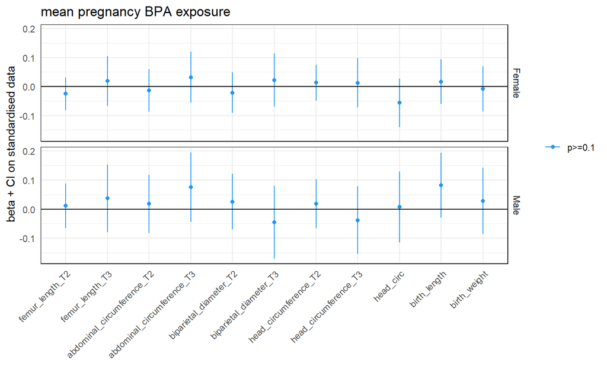

## 5.5 ln(TCS)

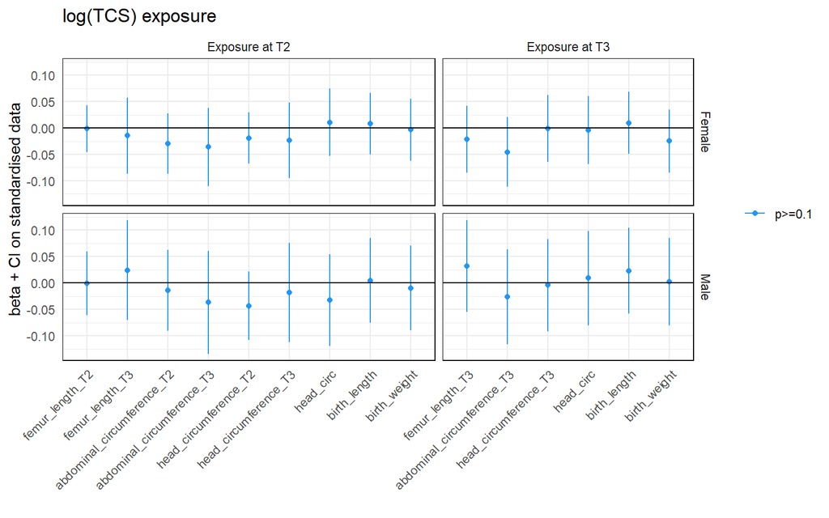

## 5.6 TCS tertiles

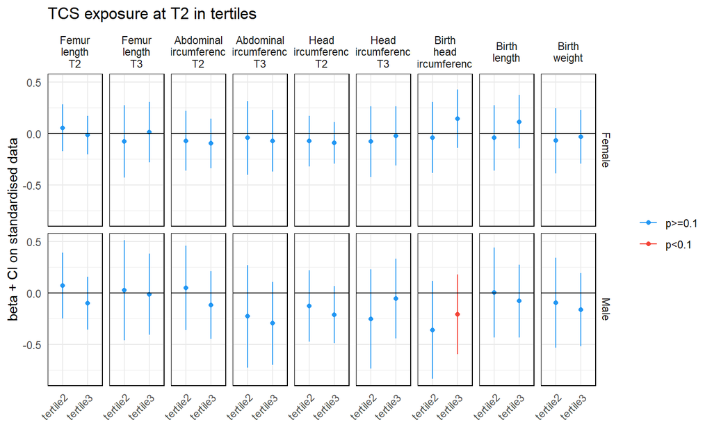

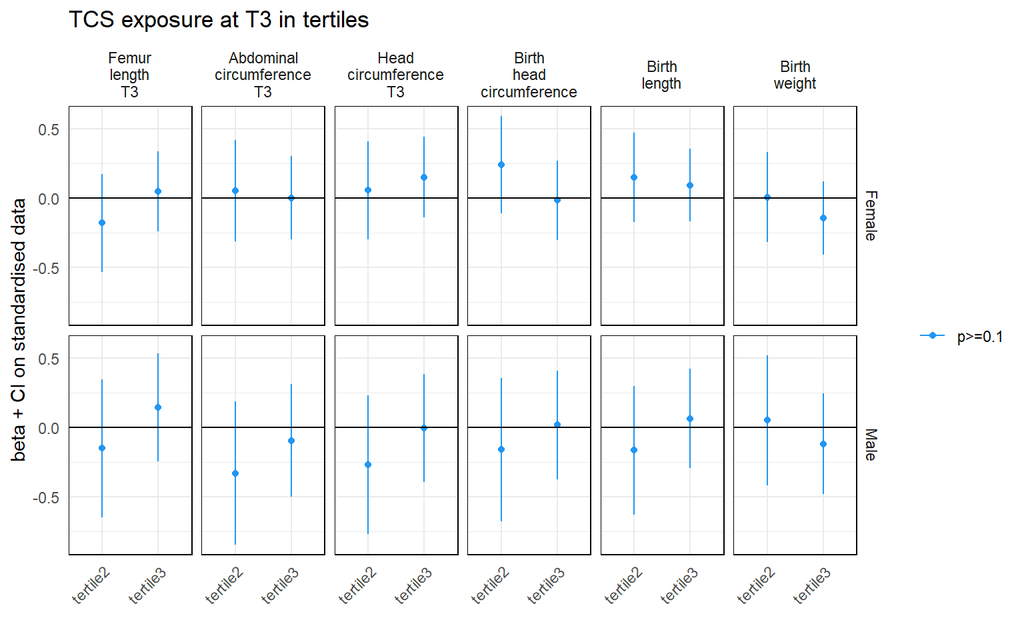

## 5.7 TCS geometric mean

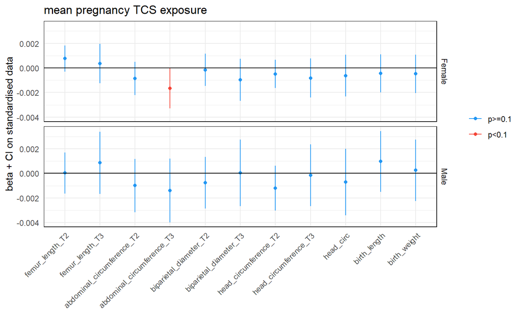

# 6 Model full outputs

## 6.1 Main models

```
## [1] "----------------------- BPA_T2 - abdominal_circumference_T2--------------------------"
##
## Call:
## lm(formula = model_formula, data = data)
##
## Residuals:
##      Min       1Q   Median       3Q      Max
## -1.82343 -0.44893 -0.03903  0.44427  2.09208
##
## Coefficients:
##                             Estimate Std. Error t value Pr(>|t|)
## (Intercept)               -1.174e+01  1.824e+01  -0.644   0.5202
## exp_val                    1.907e-02  1.988e-02   0.959   0.3381
## child_sexmale              4.237e-01  1.018e-01   4.160 4.01e-05 ***
## mom_age                    6.802e-03  1.032e-02   0.659   0.5101
## mom_weight                 9.813e-03  4.023e-03   2.439   0.0152 *
## mom_height                -2.585e-04  6.501e-03  -0.040   0.9683
## gestational_age            2.141e-01  2.336e-01   0.917   0.3600
## I(gestational_age^2)      -2.254e-04  7.543e-04  -0.299   0.7653
## mom_eduBac +3-4           -3.322e-02  8.646e-02  -0.384   0.7010
## mom_eduShorter education   4.435e-03  1.048e-01   0.042   0.9663
## paritySecond child        -7.475e-02  8.113e-02  -0.921   0.3575
## parityThird child or more -4.336e-03  1.295e-01  -0.033   0.9733
## smoke_high_t21            -3.388e-01  2.504e-01  -1.353   0.1769
## exp_val:child_sexmale     -2.965e-02  2.795e-02  -1.061   0.2894
## ---
## Signif. codes:  0 '***' 0.001 '**' 0.01 '*' 0.05 '.' 0.1 ' ' 1
##
## Residual standard error: 0.6957 on 348 degrees of freedom
##   (48 observations deleted due to missingness)
## Multiple R-squared:  0.5355, Adjusted R-squared:  0.5181
## F-statistic: 30.86 on 13 and 348 DF,  p-value: < 2.2e-16
##
## [1] "----------------------- BPA_T2 - abdominal_circumference_T3--------------------------"
##
## Call:
## lm(formula = model_formula, data = data)
##
## Residuals:
##      Min       1Q   Median       3Q      Max
```

[output cut: 1429 more lines]

```
## gestational_age            4.006e-01  2.094e-01   1.913   0.0565 .
## I(gestational_age^2)      -6.816e-04  4.570e-04  -1.491   0.1368
## mom_eduBac +3-4           -2.514e-01  1.031e-01  -2.439   0.0153 *
## mom_eduShorter education  -6.342e-02  1.244e-01  -0.510   0.6105
## paritySecond child         8.844e-03  9.607e-02   0.092   0.9267
## parityThird child or more  3.284e-01  1.537e-01   2.136   0.0334 *
## smoke_high_t21            -1.231e-01  2.776e-01  -0.444   0.6576
## exp_val:child_sexmale     -9.189e-05  8.613e-04  -0.107   0.9151
## ---
## Signif. codes:  0 '***' 0.001 '**' 0.01 '*' 0.05 '.' 0.1 ' ' 1
##
## Residual standard error: 0.816 on 340 degrees of freedom
##   (55 observations deleted due to missingness)
## Multiple R-squared:  0.3478, Adjusted R-squared:  0.3228
## F-statistic: 13.94 on 13 and 340 DF,  p-value: < 2.2e-16
```

## 6.2 ln() transformed models

```
## [1] "----------------------- BPA_T2 - abdominal_circumference_T2--------------------------"
##
## Call:
## lm(formula = model_formula, data = data)
##
## Residuals:
##      Min       1Q   Median       3Q      Max
## -1.84584 -0.43377 -0.03696  0.44899  2.06538
##
## Coefficients:
##                              Estimate Std. Error t value Pr(>|t|)
## (Intercept)                -1.174e+01  1.829e+01  -0.642   0.5211
## log(exp_val)                1.368e-02  6.388e-02   0.214   0.8305
## child_sexmale               3.713e-01  8.773e-02   4.233 2.95e-05 ***
## mom_age                     6.647e-03  1.033e-02   0.644   0.5202
## mom_weight                  9.654e-03  4.031e-03   2.395   0.0172 *
## mom_height                 -3.991e-04  6.516e-03  -0.061   0.9512
## gestational_age             2.144e-01  2.342e-01   0.916   0.3605
## I(gestational_age^2)       -2.240e-04  7.564e-04  -0.296   0.7673
## mom_eduBac +3-4            -3.335e-02  8.654e-02  -0.385   0.7002
## mom_eduShorter education    3.954e-03  1.049e-01   0.038   0.9699
## paritySecond child         -7.803e-02  8.122e-02  -0.961   0.3374
## parityThird child or more  -7.117e-03  1.298e-01  -0.055   0.9563
## smoke_high_t21             -3.396e-01  2.536e-01  -1.339   0.1813
## log(exp_val):child_sexmale -4.113e-02  8.682e-02  -0.474   0.6360
## ---
## Signif. codes:  0 '***' 0.001 '**' 0.01 '*' 0.05 '.' 0.1 ' ' 1
##
## Residual standard error: 0.6967 on 348 degrees of freedom
##   (48 observations deleted due to missingness)
## Multiple R-squared:  0.5342, Adjusted R-squared:  0.5168
## F-statistic:  30.7 on 13 and 348 DF,  p-value: < 2.2e-16
##
## [1] "----------------------- BPA_T2 - abdominal_circumference_T3--------------------------"
##
## Call:
## lm(formula = model_formula, data = data)
##
## Residuals:
##      Min       1Q   Median       3Q      Max
```

[output cut: 934 more lines]

```
## gestational_age             4.029e-01  2.091e-01   1.927 0.054842 .
## I(gestational_age^2)       -6.864e-04  4.565e-04  -1.504 0.133560
## mom_eduBac +3-4            -2.517e-01  1.030e-01  -2.444 0.015049 *
## mom_eduShorter education   -6.212e-02  1.244e-01  -0.499 0.617971
## paritySecond child          6.743e-03  9.582e-02   0.070 0.943945
## parityThird child or more   3.265e-01  1.532e-01   2.132 0.033763 *
## smoke_high_t21             -1.204e-01  2.786e-01  -0.432 0.665875
## log(exp_val):child_sexmale -2.748e-03  4.450e-02  -0.062 0.950804
## ---
## Signif. codes:  0 '***' 0.001 '**' 0.01 '*' 0.05 '.' 0.1 ' ' 1
##
## Residual standard error: 0.816 on 340 degrees of freedom
##   (55 observations deleted due to missingness)
## Multiple R-squared:  0.3477, Adjusted R-squared:  0.3228
## F-statistic: 13.94 on 13 and 340 DF,  p-value: < 2.2e-16
```

## 6.3 tertile models

```
## [1] "----------------------- BPA_T2 - abdominal_circumference_T2--------------------------"
##
## Call:
## lm(formula = model_formula, data = data)
##
## Residuals:
##      Min       1Q   Median       3Q      Max
## -1.89786 -0.40042 -0.04634  0.42683  2.02362
##
## Coefficients:
##                                  Estimate Std. Error t value Pr(>|t|)
## (Intercept)                    -1.312e+01  1.836e+01  -0.714  0.47545
## exp_val2tertile2               -1.273e-02  1.513e-01  -0.084  0.93296
## exp_val2tertile3               -7.368e-02  1.354e-01  -0.544  0.58662
## child_sexmale                   4.159e-01  1.499e-01   2.775  0.00583 **
## mom_age                         6.424e-03  1.033e-02   0.622  0.53440
## mom_weight                      9.556e-03  4.028e-03   2.372  0.01823 *
## mom_height                     -5.821e-04  6.546e-03  -0.089  0.92920
## gestational_age                 2.343e-01  2.353e-01   0.996  0.31997
## I(gestational_age^2)           -2.915e-04  7.601e-04  -0.383  0.70160
## mom_eduBac +3-4                -3.335e-02  8.648e-02  -0.386  0.70004
## mom_eduShorter education        1.234e-02  1.049e-01   0.118  0.90646
## paritySecond child             -7.272e-02  8.102e-02  -0.898  0.37006
## parityThird child or more      -9.568e-03  1.306e-01  -0.073  0.94165
## smoke_high_t21                 -3.789e-01  2.510e-01  -1.510  0.13206
## exp_val2tertile2:child_sexmale -2.258e-01  2.033e-01  -1.110  0.26757
## exp_val2tertile3:child_sexmale -3.642e-03  1.872e-01  -0.019  0.98449
## ---
## Signif. codes:  0 '***' 0.001 '**' 0.01 '*' 0.05 '.' 0.1 ' ' 1
##
## Residual standard error: 0.6952 on 346 degrees of freedom
##   (48 observations deleted due to missingness)
## Multiple R-squared:  0.5389, Adjusted R-squared:  0.5189
## F-statistic: 26.96 on 15 and 346 DF,  p-value: < 2.2e-16
##
## [1] "----------------------- BPA_T2 - abdominal_circumference_T3--------------------------"
##
## Call:
## lm(formula = model_formula, data = data)
##
```

[output cut: 994 more lines]

```
## I(gestational_age^2)           -6.900e-04  4.565e-04  -1.511 0.131618
## mom_eduBac +3-4                -2.530e-01  1.029e-01  -2.459 0.014419 *
## mom_eduShorter education       -6.674e-02  1.244e-01  -0.536 0.592070
## paritySecond child              1.965e-02  9.595e-02   0.205 0.837873
## parityThird child or more       3.462e-01  1.537e-01   2.252 0.024933 *
## smoke_high_t21                 -1.622e-01  2.795e-01  -0.580 0.562173
## exp_val2tertile2:child_sexmale -3.258e-01  2.563e-01  -1.271 0.204594
## exp_val2tertile3:child_sexmale -1.555e-01  1.999e-01  -0.778 0.437280
## ---
## Signif. codes:  0 '***' 0.001 '**' 0.01 '*' 0.05 '.' 0.1 ' ' 1
##
## Residual standard error: 0.8144 on 338 degrees of freedom
##   (55 observations deleted due to missingness)
## Multiple R-squared:  0.354,  Adjusted R-squared:  0.3254
## F-statistic: 12.35 on 15 and 338 DF,  p-value: < 2.2e-16
```

## 6.4 geometric mean models

### 6.4.1 BPA

```
## [1] "----------------------- abdominal_circumference_T2--------------------------"
##
## Call:
## lm(formula = model_formula, data = data)
##
## Residuals:
##      Min       1Q   Median       3Q      Max
## -1.86580 -0.45699 -0.04808  0.44686  2.03955
##
## Coefficients:
##                             Estimate Std. Error t value Pr(>|t|)
## (Intercept)               -1.270e+01  1.951e+01  -0.651   0.5156
## BPA_mean                  -1.355e-02  3.725e-02  -0.364   0.7163
## child_sexmale              2.987e-01  1.272e-01   2.348   0.0194 *
## mom_age                    5.278e-03  1.061e-02   0.498   0.6191
## mom_weight                 9.845e-03  4.134e-03   2.381   0.0178 *
## mom_height                -5.334e-04  6.625e-03  -0.081   0.9359
## gestational_age            2.267e-01  2.495e-01   0.909   0.3642
## I(gestational_age^2)      -2.598e-04  8.040e-04  -0.323   0.7468
## mom_eduBac +3-4           -2.447e-02  8.880e-02  -0.276   0.7830
## mom_eduShorter education   1.004e-02  1.058e-01   0.095   0.9244
## paritySecond child        -7.966e-02  8.261e-02  -0.964   0.3356
## parityThird child or more -9.603e-03  1.317e-01  -0.073   0.9419
## smoke_high_t21            -3.463e-01  2.530e-01  -1.369   0.1720
## BPA_mean:child_sexmale     3.180e-02  5.096e-02   0.624   0.5330
## ---
## Signif. codes:  0 '***' 0.001 '**' 0.01 '*' 0.05 '.' 0.1 ' ' 1
##
## Residual standard error: 0.7027 on 340 degrees of freedom
##   (56 observations deleted due to missingness)
## Multiple R-squared:  0.5242, Adjusted R-squared:  0.506
## F-statistic: 28.81 on 13 and 340 DF,  p-value: < 2.2e-16
##
## [1] "----------------------- abdominal_circumference_T3--------------------------"
##
## Call:
## lm(formula = model_formula, data = data)
##
## Residuals:
##      Min       1Q   Median       3Q      Max
```

[output cut: 307 more lines]

```
## gestational_age            4.107e-01  2.091e-01   1.965 0.050290 .
## I(gestational_age^2)      -7.026e-04  4.564e-04  -1.540 0.124601
## mom_eduBac +3-4           -2.436e-01  1.036e-01  -2.352 0.019269 *
## mom_eduShorter education  -5.791e-02  1.248e-01  -0.464 0.643044
## paritySecond child         1.082e-02  9.594e-02   0.113 0.910289
## parityThird child or more  3.540e-01  1.547e-01   2.288 0.022759 *
## smoke_high_t21            -1.252e-01  2.777e-01  -0.451 0.652485
## BPA_mean:child_sexmale    -5.156e-02  5.929e-02  -0.870 0.385060
## ---
## Signif. codes:  0 '***' 0.001 '**' 0.01 '*' 0.05 '.' 0.1 ' ' 1
##
## Residual standard error: 0.8155 on 338 degrees of freedom
##   (57 observations deleted due to missingness)
## Multiple R-squared:  0.3517, Adjusted R-squared:  0.3267
## F-statistic:  14.1 on 13 and 338 DF,  p-value: < 2.2e-16
```

### 6.4.2 TCS

```
## [1] "----------------------- abdominal_circumference_T2--------------------------"
##
## Call:
## lm(formula = model_formula, data = data)
##
## Residuals:
##      Min       1Q   Median       3Q      Max
## -1.85932 -0.46286 -0.03201  0.43618  2.04670
##
## Coefficients:
##                             Estimate Std. Error t value Pr(>|t|)
## (Intercept)               -1.379e+01  1.939e+01  -0.711   0.4774
## TCS_mean                  -8.507e-04  6.939e-04  -1.226   0.2211
## child_sexmale              3.629e-01  7.718e-02   4.702 3.75e-06 ***
## mom_age                    6.966e-03  1.058e-02   0.658   0.5107
## mom_weight                 9.576e-03  4.125e-03   2.322   0.0208 *
## mom_height                -9.238e-04  6.597e-03  -0.140   0.8887
## gestational_age            2.411e-01  2.481e-01   0.972   0.3319
## I(gestational_age^2)      -3.063e-04  7.995e-04  -0.383   0.7019
## mom_eduBac +3-4           -2.505e-02  8.829e-02  -0.284   0.7768
## mom_eduShorter education   1.418e-02  1.053e-01   0.135   0.8929
## paritySecond child        -8.695e-02  8.237e-02  -1.056   0.2919
## parityThird child or more -1.598e-02  1.311e-01  -0.122   0.9031
## smoke_high_t21            -3.549e-01  2.518e-01  -1.410   0.1596
## TCS_mean:child_sexmale    -1.375e-04  1.103e-03  -0.125   0.9009
## ---
## Signif. codes:  0 '***' 0.001 '**' 0.01 '*' 0.05 '.' 0.1 ' ' 1
##
## Residual standard error: 0.7003 on 340 degrees of freedom
##   (56 observations deleted due to missingness)
## Multiple R-squared:  0.5275, Adjusted R-squared:  0.5094
## F-statistic: 29.19 on 13 and 340 DF,  p-value: < 2.2e-16
##
## [1] "----------------------- abdominal_circumference_T3--------------------------"
##
## Call:
## lm(formula = model_formula, data = data)
##
## Residuals:
##      Min       1Q   Median       3Q      Max
```

[output cut: 307 more lines]

```
## gestational_age            4.092e-01  2.091e-01   1.957 0.051168 .
## I(gestational_age^2)      -6.992e-04  4.564e-04  -1.532 0.126468
## mom_eduBac +3-4           -2.595e-01  1.034e-01  -2.510 0.012529 *
## mom_eduShorter education  -7.034e-02  1.246e-01  -0.564 0.572888
## paritySecond child         4.142e-03  9.599e-02   0.043 0.965608
## parityThird child or more  3.412e-01  1.548e-01   2.204 0.028206 *
## smoke_high_t21            -1.231e-01  2.774e-01  -0.444 0.657426
## TCS_mean:child_sexmale     6.673e-04  1.285e-03   0.519 0.603875
## ---
## Signif. codes:  0 '***' 0.001 '**' 0.01 '*' 0.05 '.' 0.1 ' ' 1
##
## Residual standard error: 0.8154 on 338 degrees of freedom
##   (57 observations deleted due to missingness)
## Multiple R-squared:  0.3517, Adjusted R-squared:  0.3268
## F-statistic: 14.11 on 13 and 338 DF,  p-value: < 2.2e-16
```

# 7 Model residuals

Exported to `results/model_residuals/`

Outlier on femur models residuals does not drive estimations.

Matthieu Rolland

2020-03-11